Skip to main content

# HyperCom Overview

Author

Justin K. Moy & Pawel F. Przytycki

#### Last Updated: 2026-11-24

This tutorial runs HyperCom on 1,000 mouse heart cells and shows how to:

1. run the whole analysis with one call,
2. read the ranked ligand-receptor pairs,
3. score and plot the cells that send and receive a signal.

The last section runs each step on its own, for those who want to see how HyperCom works. This is the pure R version (branch `base-R`, HyperCom 0.3.1.1); the faster compiled version, with the same functions and results, is on branch `master`.

```r
library(HyperCom)
library(dplyr)
library(ggplot2)
library(ggridges)
library(Matrix)
library(tidyr)
```

## 1. Check your input

HyperCom needs three inputs. Most failed runs come from one of them, so check them first.

[output not shown]

Also:

- **Cell names must be unique.** When you merge samples, add the sample name to each barcode.
- **Cells are compared only within their sample**, so each sample needs at least 2 cells that express a ligand or receptor gene. Without `sample`, all cells are one sample.
- Cells in the counts but not in the metadata are left out, with a warning.

### The example data

A 1,000-cell subset of the heart failure data of [Alexanian et al., 2021](https://doi.org/10.1038/s41586-021-03674-1), with log-normalized counts. It comes with the package as `alexanian2021.counts` and `alexanian2021.metadata`.

```r
counts <- alexanian2021.counts
dim(counts)
```

```
[1] 17083  1000
```

```r
head(rownames(counts))
```

```
[1] "Xkr4"   "Sox17"  "Mrpl15" "Lypla1" "Tcea1"  "Rgs20"
```

```r
head(colnames(counts))
```

```
[1] "AACCGCGTCCAGAGGA-2" "AACTCAGCACGAGGTA-2" "AACTCTTGTGCGAAAC-2"
[4] "AAGGAGCAGGATCGCA-2" "ACACCAAAGACCCACC-2" "ACACCGGAGCTACCGC-2"
```

```r
cell.meta <- alexanian2021.metadata
head(cell.meta)
```

```
                   sample condition    celltype     UMAP_1     UMAP_2
AACCGCGTCCAGAGGA-2      2      SHAM Endothelial  1.2676813 -10.036637
AACTCAGCACGAGGTA-2      2      SHAM Endothelial  1.7707077  -9.448688
AACTCTTGTGCGAAAC-2      2      SHAM Endothelial  0.2925013  -9.781118
AAGGAGCAGGATCGCA-2      2      SHAM Endothelial  1.1058826 -10.454998
ACACCAAAGACCCACC-2      2      SHAM Endothelial -3.3748763 -10.034042
ACACCGGAGCTACCGC-2      2      SHAM Endothelial  3.9700553  -8.899605
```

```r
table(cell.meta$sample, cell.meta$condition)
```

```
    SHAM TAC
  2  500   0
  3    0 500
```

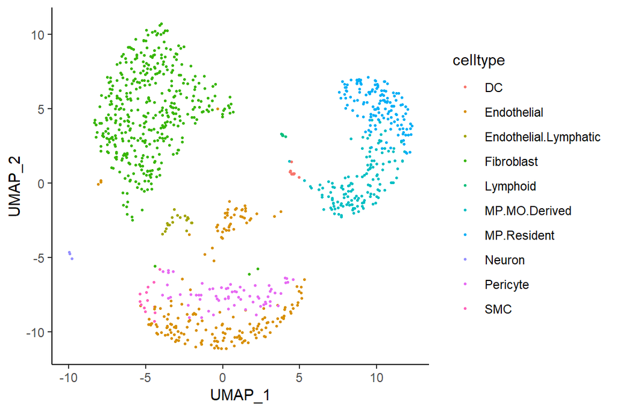

```r
ggplot(cell.meta, aes(x=UMAP_1, y=UMAP_2, colour=celltype)) +
  geom_point(size=0.5) +
  theme_classic()
```

The data is mouse, so we use the mouse database. Each row is one interaction: its name, the ligand, then the receptor genes (`NA` when the receptor has fewer subunits).

```r
lrdb <- cellchat.mm.lrdb
dim(lrdb)
```

```
[1] 2374    6
```

```r
head(lrdb, 2)
```

```
          interaction ligand     r1     r2   r3   r4
1 TGFB1_TGFBR1_TGFBR2  Tgfb1 Tgfbr1 Tgfbr2 <NA> <NA>
2 TGFB2_TGFBR1_TGFBR2  Tgfb2 Tgfbr1 Tgfbr2 <NA> <NA>
```

## 2. Run HyperCom

One call runs the whole analysis.

- HyperCom starts up to 4 R processes (one per physical core), fewer when they would not fit in memory (`threads` sets the number; `threads=1` runs in this R session alone). Results do not depend on it.
- `significance=TRUE` adds p-values; `seed` makes them reproducible.
- `prioritize=FALSE` skips ranking the pairs, which takes most of the time, for scoring chosen pairs only (section 4): `res$priority` is then `NULL` and `6.priority` is not written.

This takes about a minute.

```r
outdir <- file.path(tempdir(), "overview")
res <- HyperCom(lrdb=cellchat.mm.lrdb, counts=alexanian2021.counts,
                metadata=alexanian2021.metadata, sample="sample",
                group="condition", significance=TRUE, seed=1,
                outdir=outdir, verbose=FALSE)
```

`res` holds the results, and they are also saved to `outdir`:

| File | Contents | In `res` |
| --- | --- | --- |
| `0.counts.rds` | counts of the ligand and receptor genes |  |
| `1.lrs.csv` | interactions whose genes are all expressed | `res$lrs` |
| `2.hyperedges.csv` | hyperedges of the hypergraph |  |
| `3.adj.rds` | adjacency matrix | `res$adj` |
| `4.infMat.rds` | influence matrix | `res$infMat` |
| `5.metadata.csv` | metadata of cells and genes | `res$metadata` |
| `6.priority/priority.<weight>.csv` | ranked pairs, one file per weight | `res$priority` |

Read the CSV files with `read.csv` and the `.rds` files with `readRDS`.

```r
list.files(outdir, recursive=TRUE)
```

```
[1] "0.counts.rds"              "1.lrs.csv"
[3] "2.hyperedges.csv"          "3.adj.rds"
[5] "4.infMat.rds"              "5.metadata.csv"
[7] "6.priority/priority.1.csv"
```

### From a Seurat object or SingleCellExperiment

Same arguments, but HyperCom reads the counts and metadata from the object. `sample`, `group` and `keep` name columns of its cell metadata (`seurat[[]]` or `colData(sce)`).

```r
res <- HyperCom_seurat(seurat=seurat_object, lrdb=cellchat.mm.lrdb, sample="sample",
                       group="condition", outdir="overview")
res <- HyperCom_sce(sce=sce_object, lrdb=cellchat.mm.lrdb, sample="sample",
                    group="condition", outdir="overview")
```

- **`HyperCom_seurat`** reads the `counts` layer of the `RNA` assay by default (change with `assay` and `layer`). Works with Seurat v5 and older.
- **`HyperCom_sce`** reads the `counts` assay by default (change with `assay`). Row names must be gene symbols. Data stored on disk (DelayedArray, HDF5Array) is read only for the database genes. Needs the SingleCellExperiment package from Bioconductor.

## 3. Ranked ligand-receptor pairs

`res$priority` has one table per weight, sorted from the highest priority. A pair ranks high when the cells that express its genes:

- are a large fraction of all cells, and each of its genes is expressed in many cells,
- send or receive the signal strongly,
- split evenly into senders and receivers,
- and, with `group`, concentrate in some groups.

With `significance=TRUE`, the tables also have p-values:

- **p:** the fraction of 1,000 background pairs of random genes that rank at least as high. It moves in steps of 0.001, and 0 means none did. Background pairs that get no priority are left out, with a warning.
- **p.adj:** p with the Benjamini-Hochberg adjustment.

```r
head(res$priority[["1"]][, c("interaction", "priority", "p", "p.adj")])
```

```
        interaction  priority     p      p.adj
1        THBS1_SDC4 0.3313764 0.000 0.00000000
2        PGF_VEGFR1 0.3179562 0.000 0.00000000
3         COMP_SDC4 0.2923955 0.001 0.03688496
4          FN1_SDC4 0.2717061 0.001 0.03688496
5 POSTN_ITGAV_ITGB5 0.2651227 0.001 0.03688496
6         CCL4_CCR5 0.2645498 0.001 0.03688496
```

`weights` sets how much the fraction of cells counts. The default, 1, weighs it like the other terms; smaller values favor pairs specific to fewer cells. Several weights give one table each (see `prioritize_lr` below).

## 4. Score cells

Thbs1-Sdc4 is the top pair. `score_hypercom` scores every cell for it:

- **`sender`, `receiver`:** from 0 to 1, how strongly the cell sends or receives the signal, compared with the other cells of its sample.
- **`dif`** = receiver - sender; **`avg`** is their mean; **`max`** the larger of the two.
- **`hypercom`:** one score per cell, negative for senders and positive for receivers.
- **NaN:** the cell has no score for the pair (rare).

```r
Thbs1_Sdc4 <- score_hypercom(infMat=res$infMat, metadata=res$metadata, ligand="Thbs1",
                             receptors="Sdc4")
head(Thbs1_Sdc4[, c("cell", "sender", "receiver", "max", "hypercom")])
```

```
                cell    sender  receiver       max  hypercom
1 ATTATCCAGCTACCGC-3 0.4554808 0.9505336 0.9505336 0.6882292
2 CGTTAGAGTTACGCGC-3 0.4754217 0.9072661 0.9072661 0.6345970
3 ACTGTCCCAATAACGA-2 0.4947958 0.9135973 0.9135973 0.6245427
4 TCTCTAATCTTTAGTC-2 0.3524036 0.8681149 0.8681149 0.6053723
5 CTGAAGTAGTCGTTTG-3 0.3960002 0.8620137 0.8620137 0.6044511
6 CATTATCTCTCTGCTG-2 0.3319691 0.8752518 0.8752518 0.6017978
```

How the scores are made: each pair of cells i and j of a sample gets a score for how strongly cell i reaches the ligand and the receptor reaches cell j, relative to how strongly i reaches j. These scores are percent-ranked together. A cell’s `sender` score is its average rank as cell i, and its `receiver` score its average rank as cell j. `hypercom` is the sign of `dif` times the percent rank of its size among the cells, times `avg`.

On the UMAP, senders are blue and receivers orange. Cells that express no ligand or receptor gene are not in the hypergraph and stay grey.

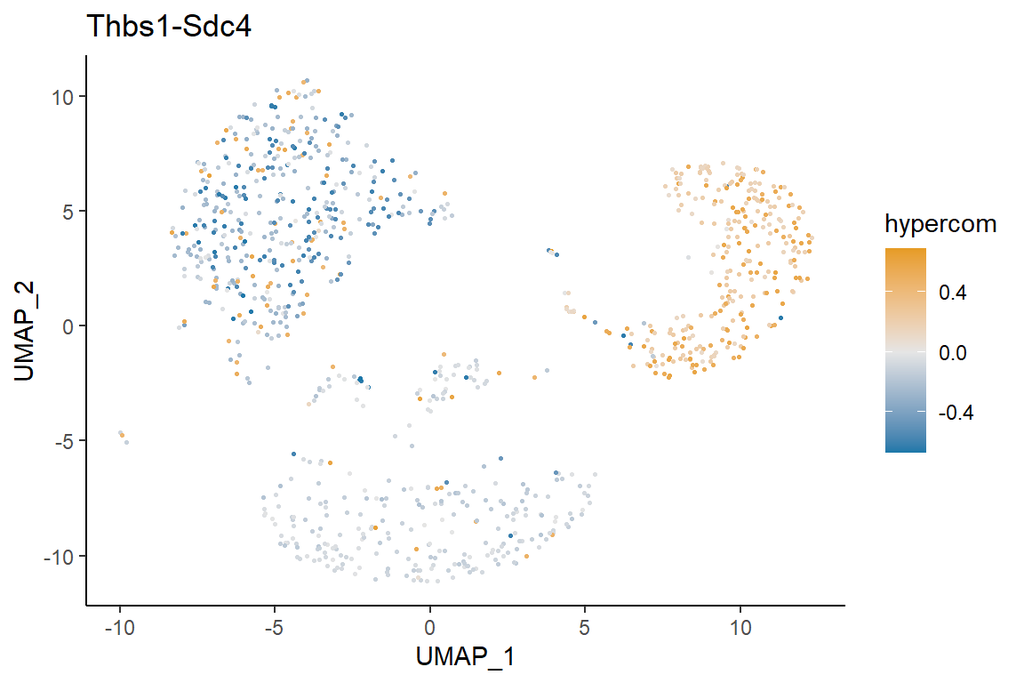

```r
umap <- data.frame(cell=rownames(cell.meta), UMAP_1=cell.meta$UMAP_1, UMAP_2=cell.meta$UMAP_2)
umap <- left_join(umap, Thbs1_Sdc4[, c("cell", "hypercom")], by=join_by(cell))
ggplot(umap, aes(x=UMAP_1, y=UMAP_2, colour=hypercom)) +
  geom_point(size=0.5) +
  scale_colour_gradient2(low="#0074a7", mid="grey90", high="#e69c25", na.value="grey70") +
  ggtitle("Thbs1-Sdc4") +
  theme_classic()
```

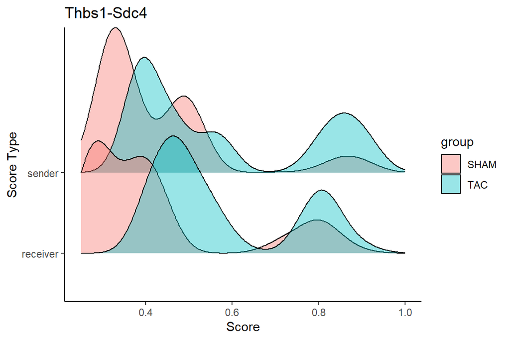

```r
Thbs1_Sdc4 <- left_join(Thbs1_Sdc4, res$metadata, by=join_by(cell))
melt.Thbs1_Sdc4 <- pivot_longer(dplyr::select(Thbs1_Sdc4, c(cell, group, sender, receiver)),
                                !c(cell, group), names_to = "type", values_to = "score")

ggplot(melt.Thbs1_Sdc4, aes(x = score, y = type, fill=group)) +
    geom_density_ridges(alpha=0.4) +
    xlim(0.25, 1) +
    xlab("Score") +
    ylab("Score Type") +
    ggtitle("Thbs1-Sdc4") +
    theme_classic()
```

For a receptor complex, give all its subunits; their scores are averaged.

```r
Tgfb1_Tgfbr <- score_hypercom(infMat=res$infMat, metadata=res$metadata, ligand="Tgfb1",
                              receptors=c("Tgfbr1", "Tgfbr2"))
head(Tgfb1_Tgfbr[, c("cell", "sender", "receiver", "hypercom")])
```

```
                cell    sender  receiver  hypercom
1 TCTGAGAGTCATCGGC-3 0.4840497 0.9397033 0.6990499
2 CGACTTCAGGATCGCA-3 0.4438649 0.8966255 0.6568269
3 GATGAAAGTTGTCGCG-3 0.4518743 0.8918048 0.6523367
4 GAAATGACAATGGACG-3 0.4362486 0.8855002 0.6463206
5 TTAGTTCAGGCTACGA-3 0.4291181 0.8830470 0.6436045
6 GGATTACCACCTTGTC-3 0.4488283 0.8776201 0.6406520
```

## 5. Large data

### Run time and memory

Time and memory depend on the number of cells **per sample** (they grow with its square), so more samples of the same size cost little. One sample, with p-values, 4 R processes (the default):

| Cells in the sample | Time | Peak memory |
| --- | --- | --- |
| 1,000 | 1.4 min | 1.8 GB |
| 3,000 | 20 min | 4.0 GB |
| 10,000 | 3.1 h | 32 GB |

Measured with `HyperCom()` on one sample of cells resampled from the bundled mouse heart data (counts thinned to 80%), with the bundled mouse database (about 1,000 pairs expressed), `significance=TRUE`, one run each, on a desktop (Intel Core i9-12900K, 128 GB). Memory is the peak of all processes together. GB = 10<sup>9</sup> bytes.

- **Pairs:** time also grows with the number of ligand-receptor pairs expressed.
- **More than about 10,000 cells per sample:** use the compiled version on branch `master`. It gives the same results, takes seconds for this tutorial and fits about 100,000 cells in one sample in 64 GB.
- **Cell scores only:** `prioritize=FALSE` skips ranking the pairs, which is almost all of this time. Each `score_hypercom` call then takes a while on large data.

### Runs that stop

Scoring the pairs takes almost all the time. As it goes, HyperCom saves the scored pairs in `<outdir>/6.priority/cache`. **If a run stops** (cluster time limit, crash, closed R session), **run the same call again.** The earlier steps repeat (seconds) and scoring continues from the cache, losing at most the last batch of pairs, e.g.:

```
  Continuing from the cache in overview/6.priority/cache: 1042 of 1042 pairs already scored
  Continuing from the cache in overview/6.priority/cache: 343 of 1000 background pairs already scored
```

- **Same results** as a run that never stopped, on the same type of computer. Without `seed`, the run keeps the background pairs it drew before the stop. `weights` and `threads` may change between the calls.
- **The cache is deleted** once the priority files are written.
- **The cache is not used**, but moved to `cache.old` with a warning, when the second call differs in the counts, the database, the cells’ sample or group, `r`, `infmat.method` or the version of HyperCom. Rename `cache.old` back to continue the run it belongs to. `resume=FALSE` turns the cache off.

## 6. Step by step: how HyperCom works

This section runs each step of `HyperCom` on its own, with `outfile=NULL` so nothing is written.

### Filter the counts

To save memory, keep only the genes of the database that are expressed (above 0). The matrix is also transposed to cells x genes.

```r
lr.counts <- filter_counts(counts=counts, lrdb=lrdb, outfile=NULL)
dim(lr.counts)
```

```
[1] 1000  663
```

Then keep only the interactions whose genes are all expressed.

```r
lrs <- generate_lrs_table(counts=lr.counts, lrdb=lrdb, outfile=NULL)
dim(lrs)
```

```
[1] 1042    5
```

### Build the hypergraph

A hyperedge links any number of nodes. HyperCom makes two types:

1. **expression edges:** a ligand or receptor gene and the cells that express it,
2. **interaction edges:** the genes of one ligand-receptor interaction.

They are stored as a data frame with an edge and a node column (a node belongs to that edge), each edge with weight 1. Cells and genes not connected to the rest are left out (see section 5).

```r
hyperedges <- generate_hyperedges(counts=lr.counts, lrs=lrs, outfile=NULL)
head(hyperedges, 2)
```

```
# A tibble: 2 × 3
  edge                node   weight
  <chr>               <chr>   <dbl>
1 TGFB1_TGFBR1_TGFBR2 Tgfb1       1
2 TGFB1_TGFBR1_TGFBR2 Tgfbr1      1
```

The adjacency matrix has the cells, ligand genes and receptor genes as nodes; each entry is the number of hyperedges two nodes share. It is not stored in full: `adj` keeps which nodes are in which hyperedge, which is much smaller, and works like a matrix (`dim(adj)`, `adj[i, j]`, `as.matrix(adj)` for the whole matrix).

```r
adj <- generate_adjacency_matrix(hyperedges=hyperedges, outfile=NULL)
dim(adj)
```

```
[1] 1663 1663
```

```r
adj[c("Thbs1", "Sdc4"), 1:3]
```

```
       node
node    AAAGATGCACAGATTC-3 AAAGATGCAGCTCGCA-3 AAAGATGCAGGTCTCG-3
  Thbs1                  1                  1                  0
  Sdc4                   0                  0                  0
```

### Compute the influence matrix

A random walk with restart on the adjacency matrix gives the influence matrix: entry (i, j) is the share of a walk started at node i that ends at node j, so each row sums to 1. At every step the walk returns to its start with the restart probability `r`, so about `r` of each node’s influence stays on itself and the rest spreads over the nodes it shares hyperedges with.

`generate_infMat` and `HyperCom` take `r` (default 0.5). Like `adj`, `infMat` works like a matrix without being stored in full (section 5).

```r
infMat <- generate_infMat(adj=adj, r=0.5, outfile=NULL)
dim(infMat)
```

```
[1] 1663 1663
```

```r
infMat[c("Thbs1", "Sdc4"), 1:3]
```

```
       node
node    AAAGATGCACAGATTC-3 AAAGATGCAGCTCGCA-3 AAAGATGCAGGTCTCG-3
  Thbs1        0.001564199       0.0015831587       0.0002673712
  Sdc4         0.000335307       0.0003461792       0.0002531521
```

### Prepare the metadata

The matrices now have genes as well as cells, so the metadata gets a row per gene too, with `"gene"` in each column. To save memory, only the cell, sample and group columns are kept; `keep` adds others.

```r
node.meta <- generate_metadata(infMat=infMat, metadata=cell.meta,
                               sample="sample", group="condition",
                               keep=NULL, outfile=NULL)
head(node.meta)
```

```
                cell sample group
1 AAAGATGCACAGATTC-3      3   TAC
2 AAAGATGCAGCTCGCA-3      3   TAC
3 AAAGATGCAGGTCTCG-3      3   TAC
4 AAAGATGGTGTTTGGT-2      2  SHAM
5 AAAGTAGAGGAGTTTA-2      2  SHAM
6 AAAGTAGCACATTTCT-2      2  SHAM
```

### Rank the pairs

`prioritize_lr` ranks the pairs (section 3). The priority is the weighted geometric mean of five terms of the cells that express the pair’s genes: their fraction of all cells, the smallest fraction of cells expressing one of its genes, the mean of each cell’s larger score as sender or receiver, how evenly they split into senders and receivers, and how much they concentrate in some groups. `weights` is the weight of the first term; here two weights give two tables.

```r
priority <- prioritize_lr(lrs=lrs, adj=adj, infMat=infMat, metadata=node.meta,
                          weights=c(1, 0.5), outdir=NULL, verbose=FALSE)
head(priority[["1"]])
```

```
        interaction ligand    r1    r2   r3  priority
1        THBS1_SDC4  Thbs1  Sdc4  <NA> <NA> 0.3313764
2        PGF_VEGFR1    Pgf  Flt1  <NA> <NA> 0.3179562
3         COMP_SDC4   Comp  Sdc4  <NA> <NA> 0.2923955
4          FN1_SDC4    Fn1  Sdc4  <NA> <NA> 0.2717061
5 POSTN_ITGAV_ITGB5  Postn Itgav Itgb5 <NA> 0.2651227
6         CCL4_CCR5   Ccl4  Ccr5  <NA> <NA> 0.2645498
```

## Citation

If you use HyperCom, please cite: Moy JK, Przytycki PF (2026). HyperCom: a hypergraph-based method to infer cell-resolved cell-cell communication. *bioRxiv*. [doi:10.64898/2026.09.30.755742](https://doi.org/10.64898/2026.09.30.755742)